# Prediciendo el precio del Dolar Blue con ARIMA

En este notebook vamos a predecir el valor del dólar en el mercado informal utilizando como datos los valores de años anteriores.

```python
import requests, pandas as pd, numpy as np
from pandas import DataFrame
from io import StringIO
import time, json
from datetime import date
import statsmodels
from statsmodels.tsa.stattools import adfuller, acf, pacf
from statsmodels.tsa.arima_model import ARIMA
from statsmodels.tsa.seasonal import seasonal_decompose
from sklearn.metrics import mean_squared_error
import matplotlib.pylab as plt
%matplotlib inline
from matplotlib.pylab import rcParams
rcParams['figure.figsize'] = 15, 6
```

### Cargando la Data

Se trata de un archivo CSV que tiene registrado el valor del dólar en el mercado informal (dolar blue) para cada día del año desde 2011.

```python
deida = pd.read_csv('USD_ARS-informal-market.csv')
deida.Value = pd.to_numeric(deida.Value)
```

```python
deida.head()
```

|  | Date | Value |
| --- | --- | --- |
| 0 | 3-01-2011 | 4.11 |
| 1 | 4-01-2011 | 4.12 |
| 2 | 5-01-2011 | 4.14 |
| 3 | 6-01-2011 | 4.14 |
| 4 | 7-01-2011 | 4.12 |

```python
deida['Date'] = pd.to_datetime(deida['Date'], format = '%d-%m-%Y')
```

```python
indexed_df = deida.set_index('Date')
```

```python
# Aqui hacemos una Time Series
ts = indexed_df['Value']
ts.head(5)
```

```
Date
2011-01-03    4.11
2011-01-04    4.12
2011-01-05    4.14
2011-01-06    4.14
2011-01-07    4.12
Name: Value, dtype: float64
```

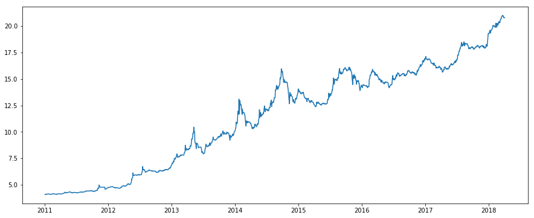

```python
plt.plot(ts.index.to_pydatetime(), ts.values)
```

### Resampleando la data en la serie temporal

La variacion diaria es muy grande, asi que se resamplea para tener la data por semana.

```python
ts_week = ts.resample('W').mean()
```

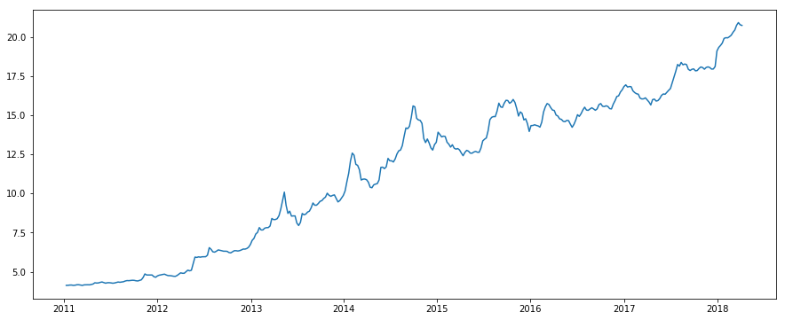

```python
plt.plot(ts_week.index.to_pydatetime(), ts_week.values)
```

### Comprobando que la serie temporal es estacionaria.

Que se quiere decir con comprobar si la serie temporal es estacionaria y por que nos importa?

En una serie de tiempo estacionaria, las propiedades estadísticas deben ser constantes en el tiempo y la autocovarianza debe ser dependiente del tiempo. Normalmente, cuando se corre una regresión normal, uno espera que las observaciones sean independientes entre sí. Sin embargo, en una serie temporal uno tiene certeza que las observaciones dependen del tiempo. Para poder usar técnicas de regresión en variables dependientes del tiempo la data debe ser estacionaria. Las técnicas que aplican a variables independientes aleatorias tambien aplican a variables aleatorias estacionarias.

Hay dos formas de comprobar si una serie de tiempo es estacionaria. La primera es ploear la varianza móvil y observar si se mantiene constante en el tiempo. Pero no siempre es posible hacer inferencias visuales. La otra forma es usar el test de Dickey-Fuller, un test estadístico cuya hipótesis nula es que la serie temporal es no-estacionaria. Si el test resulta en que la estadística del test es significativamente menos que el valor crítico preestablecido, podemos rechazar la hipótesis nula en favor de tomar la serie temporal como estacionaria.

Ahora calculamos la varianza móvil, ploteamos los resultados y aplicamos el test de Dickey-Fuller en la serie temporal:

```python
def test_stationarity(timeseries):

    #Determing rolling statistics
    rolmean = timeseries.rolling(window=52,center=False).mean()
    rolstd = timeseries.rolling(window=52,center=False).std()

    #Plot rolling statistics:
    orig = plt.plot(timeseries.index.to_pydatetime(), timeseries.values, color='blue',label='Original')
    mean = plt.plot(rolmean.index.to_pydatetime(), rolmean.values, color='red', label='Media móvil')
    std = plt.plot(rolstd.index.to_pydatetime(), rolstd.values, color='black', label = 'Desvío móvil')
    plt.legend(loc='best')
    plt.title('Media y desvío estandard móviles')
    plt.show(block=False)

    #Perform Dickey-Fuller test:
    print ('Results of Dickey-Fuller Test:')
    dftest = adfuller(timeseries, autolag='AIC')
    dfoutput = pd.Series(dftest[0:4], index=['Test Statistic','p-value','#Lags Used','Number of Observations Used'])
    for key,value in dftest[4].items():
        dfoutput['Critical Value (%s)'%key] = value
    print (dfoutput)
```

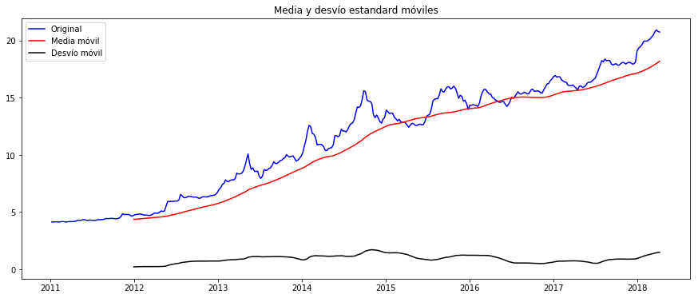

```
Results of Dickey-Fuller Test:
Test Statistic                   0.066983
p-value                          0.963733
#Lags Used                      15.000000
Number of Observations Used    363.000000
Critical Value (1%)             -3.448494
Critical Value (5%)             -2.869535
Critical Value (10%)            -2.571029
dtype: float64
```

```python
test_stationarity(ts_week)
```

Se puede ver que la estadística del test es mayor que el valor crítico de 5% y el p-valor es más grande que 0.05, la media móvil no es constante en el tiempo y la hipótesis nula del test Dickey-Fuller no se puede rechazar. Esto mustra que la serie de tiempo semana no es estacionaria.

Antes de que podamos aplicar el modelo ARIMA para predicciones, necesitamos transformar esta serie de tiempo en una serie de tiempo estacionaria.

## Estacionarizando la serie temporal

Si la serie de tiempo revela una tendencia o estacionalidad (no confundir estacional con estacionario), es una indicación de que es no-estacionaria. Podemos estacionarizar la serie temporal mediante calcular la tendencia y estacionalidad y remover estos factores del modelo. Se pueden aplicar diferentes transformaciones para estacionarizar la data como se verá a continuación.

### Aplicando una transformación logarítmica no lineal (re-escalando la serie temporal)

```python
ts_week_log = np.log(ts_week)
```

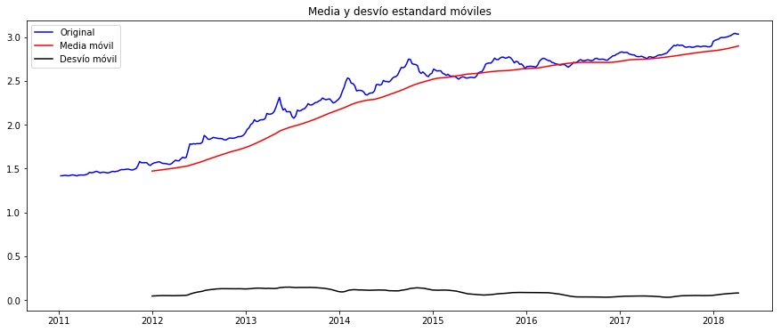

```
Results of Dickey-Fuller Test:
Test Statistic                  -1.538721
p-value                          0.514277
#Lags Used                      15.000000
Number of Observations Used    363.000000
Critical Value (1%)             -3.448494
Critical Value (5%)             -2.869535
Critical Value (10%)            -2.571029
dtype: float64
```

```python
test_stationarity(ts_week_log)
```

El resultado del test de Dickey-Fuller confirma que la serie temporal es todavía no estacionaria. (Test statistic > 5% , p-value> 0.05)

### Quitando tendencias y estacionalidad con descomposición

Los resultados de la descomposición muestran una tendencia y un efecto estacional con un ciclo de aproximadamente 12 meses para las semanas más recientes del dataset.

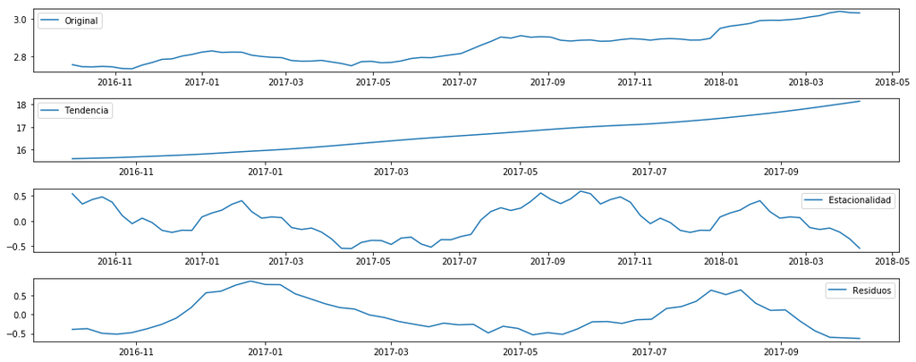

```python
decomposition = seasonal_decompose(ts_week)

trend = decomposition.trend
seasonal = decomposition.seasonal
residual = decomposition.resid

ts_week_log_select = ts_week_log[-80:]

plt.subplot(411)
plt.plot(ts_week_log_select.index.to_pydatetime(), ts_week_log_select.values, label='Original')
plt.legend(loc='best')
plt.subplot(412)
plt.plot(ts_week_log_select.index.to_pydatetime(), trend[-80:].values, label='Tendencia')
plt.legend(loc='best')
plt.subplot(413)
plt.plot(ts_week_log_select.index.to_pydatetime(), seasonal[-80:].values,label='Estacionalidad')
plt.legend(loc='best')
plt.subplot(414)
plt.plot(ts_week_log_select.index.to_pydatetime(), residual[-80:].values, label='Residuos')
plt.legend(loc='best')
plt.tight_layout()
```

Ahora que las tendencias y la estacionalidad están identificadas se hace posible modelar los residuos (fit lines between values in the plot). Sin embargo, como los patrones de tendencia y la información de la estacionalidad extraídos de la serie temporal que están ploteados despues de la descomposición todavía no son consistentes y no se pueden escalar de vuelta a los valores originales, todavía no se puede usar este enfoque para crear predicciones confiables.

### Quitando tendencias y estacionalidad con diferenciación

La diferenciación (differencing) es uno de los métodos más comunes para tratar tanto la tendencia como la estacionalidad. En diferenciación de primer orden, se calculan las "diferencias" entre observaciones consecutivas en la serie temporal. Esto suele mejorar la estacionalidad en la serie de tiempo. En el código esto se confirma realizando el test de Dickey-Fuller.

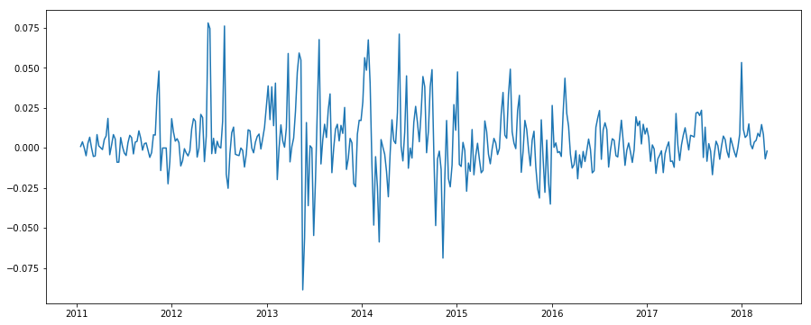

```python
ts_week_log_diff = ts_week_log - ts_week_log.shift()
plt.plot(ts_week_log_diff.index.to_pydatetime(), ts_week_log_diff.values)
```

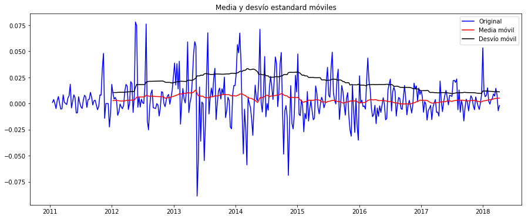

```
Results of Dickey-Fuller Test:
Test Statistic                -5.978886e+00
p-value                        1.858909e-07
#Lags Used                     1.400000e+01
Number of Observations Used    3.630000e+02
Critical Value (1%)           -3.448494e+00
Critical Value (5%)           -2.869535e+00
Critical Value (10%)          -2.571029e+00
dtype: float64
```

```python
ts_week_log_diff.dropna(inplace=True)
test_stationarity(ts_week_log_diff)
```

Los resultados muestran que la estadística del test es significativamente menos que el valor crítico de 1%. Esto significa que la serie temporal es estacionaria con 99% de confianza. Ahora se pueden aplicar modelos estadísticos como ARIMA sobre esta serie de tiempo estacionaria.

## Encontrando parámetros óptimos y construyendo el modelo ARIMA

Para aplicar ARIMA a la serie temporal es necesario encontrar los valores óptimos para los tres parámetros siguientes (p,d,q):

- (p) El número de términos autoregresivos (AR): Los términos AR son simplemente desfases de la variable dependiente (el tipo de cambio en este dataset). Entonces, p=2 significa que los predictores de x(t) son x(t-1) y x(t-2).
- (q) El número de términos de media móvil (MA) : Los términos MA son errores desfasados de predicción en la ecuación predictiva. Por ejemplo, con q=2 los predictores de x(t) son e(t-1) y e(t-2) donde e(i) es la diferencia entre la media móvil en el instante iésimo y el valor verdadero.
- El número de diferencias (d): Estos son los números de diferencias no estacionales. En nuestro caso, d=1ya que estamos usando una serie de tiempo diferenciada en el primer orden.

Hay dos maneras de determinar el número de términos AR y MA. La primera es usar la función arma_order_select_ic de Python. La segunda utiliza los gráficos de la función de autocorrelación (ACF) y la función de autocorrelacion parcial (PACF).

### Ploteando la función de autocorrelación (ACF) y la función de autocorrelación parcial (PACF)

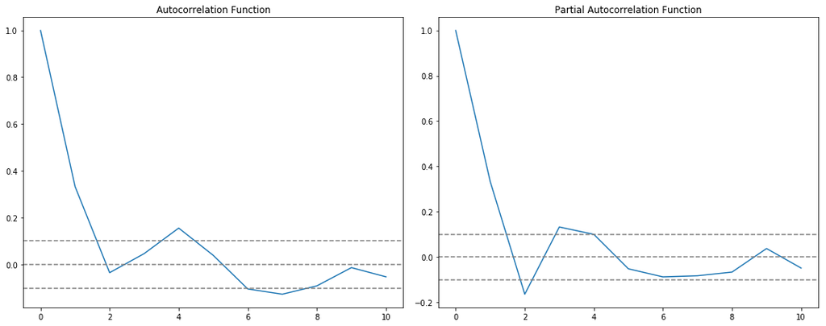

```python
#ACF and PACF plots

lag_acf = acf(ts_week_log_diff, nlags=10)
lag_pacf = pacf(ts_week_log_diff, nlags=10, method='ols')

#Plot ACF:
plt.subplot(121)
plt.plot(lag_acf)
plt.axhline(y=0,linestyle='--',color='gray')
plt.axhline(y=-1.96/np.sqrt(len(ts_week_log_diff)),linestyle='--',color='gray')
plt.axhline(y=1.96/np.sqrt(len(ts_week_log_diff)),linestyle='--',color='gray')
plt.title('Autocorrelation Function')

#Plot PACF:
plt.subplot(122)
plt.plot(lag_pacf)
plt.axhline(y=0,linestyle='--',color='gray')
plt.axhline(y=-1.96/np.sqrt(len(ts_week_log_diff)),linestyle='--',color='gray')
plt.axhline(y=1.96/np.sqrt(len(ts_week_log_diff)),linestyle='--',color='gray')
plt.title('Partial Autocorrelation Function')
plt.tight_layout()
```

En este gráfico, los valores 'p' y 'q' pueden ser determinados como sigue:

- p: El valor donde la curva PACF corta el 0 por primera vez. (p=2)
- q: El valor donde la curva ACF cruza el intervalo de confianza superior por primera vez. (q=2, q=1 tambien podría funcionar)

Esto significa que los valores óptimos para el modelo ARIMA(p,d,q) son (2,1,2).

Si los valores sugeridos por los gráficos de ACF y PACF difieren de los valores obtenidos por la función arma_order_select_ic, se deben probar valores para los terminos p y q y usar los resultados del modelos ajustados para obtener sus valores AIC y proceder con con el modelo que tenga un menor valor de AIC.

La siguiente línea de código ajusta la data usando el modelo ARIMA con valores (2,1,2):

```python
model = ARIMA(ts_week_log, order=(2, 1, 2))
results_ARIMA = model.fit(disp=-1)
```

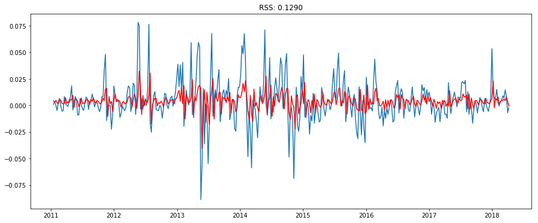

```python
model = ARIMA(ts_week_log, order=(2, 1, 1))
results_ARIMA = model.fit(disp=-1)
plt.plot(ts_week_log_diff.index.to_pydatetime(), ts_week_log_diff.values)
plt.plot(ts_week_log_diff.index.to_pydatetime(), results_ARIMA.fittedvalues, color='red')
plt.title('RSS: %.4f'% sum((results_ARIMA.fittedvalues-ts_week_log_diff)**2))
```

### Midiendo la varianza entre la data y los valores predichos por el modelo

Se puede medir si los resultados del modelo se ajustan a la data subyacente mediante la métrica de la suma de residuos cuadrados (RSS). Un valor bajo de RSS sugiere que el modelo se ajusta a la data.

Otro enfoque para validar si el modelo ARIMA es apropiado consiste en realizar análisis de residuos.

A continuación se imprimen los parámetros del modelo ARIMA y se grafican los residuos. Un gráfico de densidades de los valores de error residual indica una distribución normal centrada en cero. Además los residuos no violan el supuesto de ubicación constante y escala ya que la mayor parte de los valores se encuentra en el rango (-1,1).

```
                             ARIMA Model Results
==============================================================================
Dep. Variable:                D.Value   No. Observations:                  378
Model:                 ARIMA(2, 1, 1)   Log Likelihood                 972.357
Method:                       css-mle   S.D. of innovations              0.018
Date:                Thu, 10 May 2018   AIC                          -1934.714
Time:                        23:37:48   BIC                          -1915.040
Sample:                    01-16-2011   HQIC                         -1926.906
                         - 04-08-2018
=================================================================================
                    coef    std err          z      P>|z|      [0.025      0.975]
---------------------------------------------------------------------------------
const             0.0043      0.001      3.381      0.001       0.002       0.007
ar.L1.D.Value     0.0950      0.179      0.532      0.595      -0.255       0.445
ar.L2.D.Value    -0.0766      0.083     -0.920      0.358      -0.240       0.087
ma.L1.D.Value     0.3060      0.174      1.762      0.079      -0.034       0.646
                                    Roots
=============================================================================
                 Real           Imaginary           Modulus         Frequency
-----------------------------------------------------------------------------
AR.1            0.6200           -3.5593j            3.6129           -0.2226
AR.2            0.6200           +3.5593j            3.6129            0.2226
MA.1           -3.2679           +0.0000j            3.2679            0.5000
-----------------------------------------------------------------------------
                0
count  378.000000
mean     0.000002
std      0.018495
min     -0.104526
25%     -0.007766
50%     -0.000731
75%      0.008331
max      0.069493
```

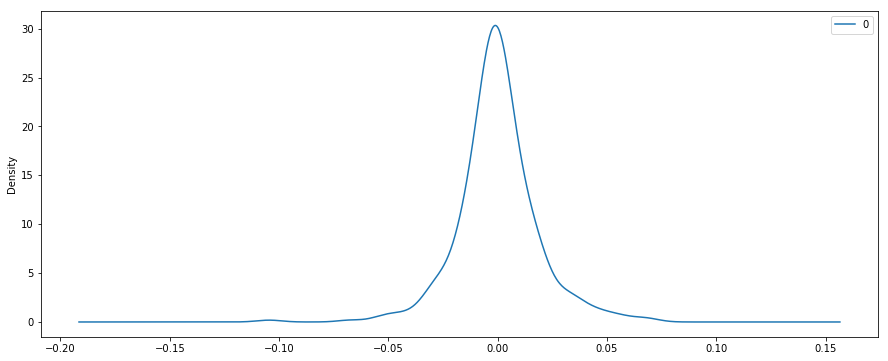

```python
print(results_ARIMA.summary())
# plot residual errors
residuals = DataFrame(results_ARIMA.resid)
residuals.plot(kind='kde')
print(residuals.describe())
```

Esto confirma un buen resultado del modelo. La simetría nos indica que no hay ningún sesgo en el modelo.

### Escalar las predicciones

En esta instancia el modelo se desempeña correctamente, asi que se pueden escalar las predicciones del modelo de vuelta a su escala original. Para esto se remueve la diferenciación de primer orden y se toma el exponente para restaurar las predicciones a asu escala original.

Valores más cercanos a cero de la raíz media cuadrada del error (RMSE), indican que las predicciones del modelo son más cercanos a los valores verdaderos.

```python
predictions_ARIMA_diff = pd.Series(results_ARIMA.fittedvalues, copy=True)
print (predictions_ARIMA_diff.head())
```

```
Date
2011-01-16    0.004272
2011-01-23    0.003174
2011-01-30    0.004692
2011-02-06    0.002466
2011-02-13    0.001500
Freq: W-SUN, dtype: float64
```

```python
predictions_ARIMA_diff_cumsum = predictions_ARIMA_diff.cumsum()
predictions_ARIMA_log = pd.Series(ts_week_log.iloc[0], index=ts_week_log.index)
predictions_ARIMA_log = predictions_ARIMA_log.add(predictions_ARIMA_diff_cumsum,fill_value=0)
```

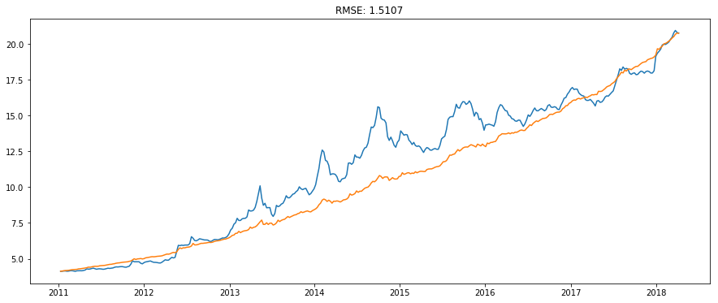

```python
predictions_ARIMA = np.exp(predictions_ARIMA_log)
plt.plot(ts_week.index.to_pydatetime(), ts_week.values)
plt.plot(ts_week.index.to_pydatetime(), predictions_ARIMA.values)
plt.title('RMSE: %.4f'% np.sqrt(sum((predictions_ARIMA-ts_week)**2)/len(ts_week)))
```

## Haciendo predicciones en la serie temporal

Lo que se ha logrado en este notebook hasta aqui es una predicción dentro de la muestra usando ARIMA al entrenar el modelo en la toda ladata de la serie temporal. Ahora se necesita separar el dataset en conjuntos de training y test. Se usará el dataset de training para entrenar el modelo ARIMA y realizar una predicción fuera de la muestra. Luego se compararán los resultados de las predicciones fuera de la muestra con los valore de dataset de test.

Se usará la función "forecast" para realizar una predicción móvil de un-paso con ARIMA. Una predicción móvil esrequerida dada la dependencia en las observaciones durante la diferenciación y el modelo AR. Se re-creará el modelo ARIMA después de que cada nueva prediction sea recibida. Y manualmente se mantendrá registro de todas las observaciones en una lista llamada history, la cual tiene una semilla en la data de training y para la cual nuevas predicciones son incorporadas en cada iteración.

```python
size = int(len(ts_week_log) - 15)
train, test = ts_week_log[0:size], ts_week_log[size:len(ts_week_log)]
history = [x for x in train]
predictions = list()

print('Valores predichos vs Valores Esperados')
print('\n')
for t in range(len(test)):
    model = ARIMA(history, order=(2,1,1))
    model_fit = model.fit(disp=0)
    output = model_fit.forecast()
    yhat = output[0]
    predictions.append(float(yhat))
    obs = test[t]
    history.append(obs)
    print('Predicción=%f, Esperado=%f' % (np.exp(yhat), np.exp(obs)))

error = mean_squared_error(test, predictions)

print('\n')
print('Error medio cuadrático de las predicciones')
print('MSE: %.6f' % error)

predictions_series = pd.Series(predictions, index = test.index)
```

```
Valores predichos vs Valores Esperados


Predicción=18.242773, Esperado=19.125000
Predicción=19.574189, Esperado=19.350000
Predicción=19.302818, Esperado=19.478000
Predicción=19.607841, Esperado=19.632000
Predicción=19.726033, Esperado=19.930000
Predicción=20.093538, Esperado=19.974000
Predicción=20.002575, Esperado=19.964000
Predicción=20.031469, Esperado=20.038000
Predicción=20.131728, Esperado=20.134000
Predicción=20.222472, Esperado=20.320000
Predicción=20.445793, Esperado=20.466000
Predicción=20.557873, Esperado=20.768000
Predicción=20.938634, Esperado=20.942000
Predicción=21.025173, Esperado=20.800000
Predicción=20.792341, Esperado=20.760000


Error medio cuadrático de las predicciones
MSE: 0.000189
```

Se ha validado el modelo mediante comparar sus predicciones fuera de la muestra con los valores verdaderos del dataset de prueba calculando el error medio cuadrado. A continuación se plotean las predicciones del modelo contra los valores observados. Se puede notar que las predicciones estan en la escala correcta y reproducen la tendencia de la serie de tiempo original.

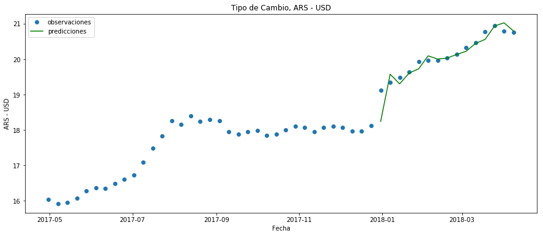

```python
fig, ax = plt.subplots()
ax.set(title='Tipo de Cambio, ARS - USD', xlabel='Fecha', ylabel='ARS - USD')
ax.plot(ts_week[-50:], 'o', label='observaciones')
ax.plot(np.exp(predictions_series), 'g', label='predicciones')
legend = ax.legend(loc='upper left')
legend.get_frame().set_facecolor('w')
```

Cada punto representa una semana. Se puede observar como el modelo reproduce la tendencia a principio de año.

## Sumario

- Cargar y visualizar la serie temporal
- Comprobar la estacionaridad.
- Aplicar transformaciones para obtener un comportamiento estacionario.
- Encontrar los valore óptimos para los parámetros del modelo ARIMA
- Usar el modelo para hacer predicciones.

Data obtenida de https://docs.google.com/spreadsheets/d/1VfAUEuoNHkR7HG_KHgA5ZT-3nwdl1zOtT_VvvgfJx5g/export?format=csv&id=1VfAUEuoNHkR7HG_KHgA5ZT-3nwdl1zOtT_VvvgfJx5g&gid=0